# RedWineDataSetEDA

Load libraries and load CSV file, explore data we have and remove variable x

```
## [1] "C:/Users/ah353c/Desktop/AT&T Las Vegas/2020 training/NanoDegree/Data Analyst/Module 7/Project/RMD/Send4"
```

```
##  [1] "X"                    "fixed.acidity"        "volatile.acidity"
##  [4] "citric.acid"          "residual.sugar"       "chlorides"
##  [7] "free.sulfur.dioxide"  "total.sulfur.dioxide" "density"
## [10] "pH"                   "sulphates"            "alcohol"
## [13] "quality"
```

```
## 'data.frame':    1599 obs. of  13 variables:
##  $ X                   : int  1 2 3 4 5 6 7 8 9 10 ...
##  $ fixed.acidity       : num  7.4 7.8 7.8 11.2 7.4 7.4 7.9 7.3 7.8 7.5 ...
##  $ volatile.acidity    : num  0.7 0.88 0.76 0.28 0.7 0.66 0.6 0.65 0.58 0.5 ...
##  $ citric.acid         : num  0 0 0.04 0.56 0 0 0.06 0 0.02 0.36 ...
##  $ residual.sugar      : num  1.9 2.6 2.3 1.9 1.9 1.8 1.6 1.2 2 6.1 ...
##  $ chlorides           : num  0.076 0.098 0.092 0.075 0.076 0.075 0.069 0.065 0.073 0.071 ...
##  $ free.sulfur.dioxide : num  11 25 15 17 11 13 15 15 9 17 ...
##  $ total.sulfur.dioxide: num  34 67 54 60 34 40 59 21 18 102 ...
##  $ density             : num  0.998 0.997 0.997 0.998 0.998 ...
##  $ pH                  : num  3.51 3.2 3.26 3.16 3.51 3.51 3.3 3.39 3.36 3.35 ...
##  $ sulphates           : num  0.56 0.68 0.65 0.58 0.56 0.56 0.46 0.47 0.57 0.8 ...
##  $ alcohol             : num  9.4 9.8 9.8 9.8 9.4 9.4 9.4 10 9.5 10.5 ...
##  $ quality             : int  5 5 5 6 5 5 5 7 7 5 ...
```

```
##        X          fixed.acidity   volatile.acidity  citric.acid
##  Min.   :   1.0   Min.   : 4.60   Min.   :0.1200   Min.   :0.000
##  1st Qu.: 400.5   1st Qu.: 7.10   1st Qu.:0.3900   1st Qu.:0.090
##  Median : 800.0   Median : 7.90   Median :0.5200   Median :0.260
##  Mean   : 800.0   Mean   : 8.32   Mean   :0.5278   Mean   :0.271
##  3rd Qu.:1199.5   3rd Qu.: 9.20   3rd Qu.:0.6400   3rd Qu.:0.420
##  Max.   :1599.0   Max.   :15.90   Max.   :1.5800   Max.   :1.000
##  residual.sugar     chlorides       free.sulfur.dioxide
##  Min.   : 0.900   Min.   :0.01200   Min.   : 1.00
##  1st Qu.: 1.900   1st Qu.:0.07000   1st Qu.: 7.00
##  Median : 2.200   Median :0.07900   Median :14.00
##  Mean   : 2.539   Mean   :0.08747   Mean   :15.87
##  3rd Qu.: 2.600   3rd Qu.:0.09000   3rd Qu.:21.00
##  Max.   :15.500   Max.   :0.61100   Max.   :72.00
##  total.sulfur.dioxide    density             pH          sulphates
##  Min.   :  6.00       Min.   :0.9901   Min.   :2.740   Min.   :0.3300
##  1st Qu.: 22.00       1st Qu.:0.9956   1st Qu.:3.210   1st Qu.:0.5500
##  Median : 38.00       Median :0.9968   Median :3.310   Median :0.6200
##  Mean   : 46.47       Mean   :0.9967   Mean   :3.311   Mean   :0.6581
##  3rd Qu.: 62.00       3rd Qu.:0.9978   3rd Qu.:3.400   3rd Qu.:0.7300
##  Max.   :289.00       Max.   :1.0037   Max.   :4.010   Max.   :2.0000
##     alcohol         quality
##  Min.   : 8.40   Min.   :3.000
##  1st Qu.: 9.50   1st Qu.:5.000
##  Median :10.20   Median :6.000
##  Mean   :10.42   Mean   :5.636
##  3rd Qu.:11.10   3rd Qu.:6.000
##  Max.   :14.90   Max.   :8.000
```

Creating a new variable: wine_quality. very.good >= 7, good >= 5, bad < 5.

```
##  chr [1:1599] "good" "good" "good" "good" "good" "good" "good" ...
```

```
## Length  Class   Mode
##      0   NULL   NULL
```

Using grid.arrange to show plots next to each other and Grouping plots by their chemical catagegories

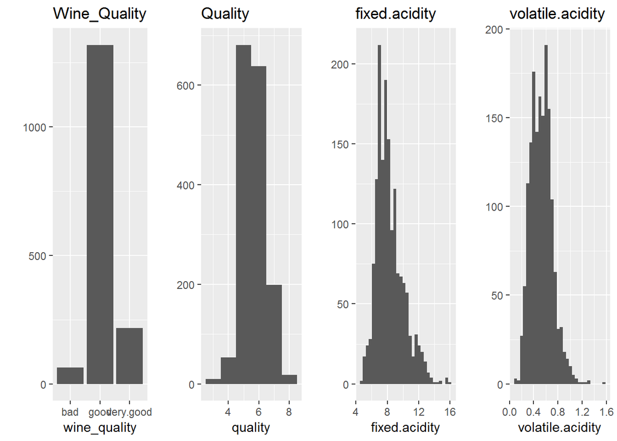

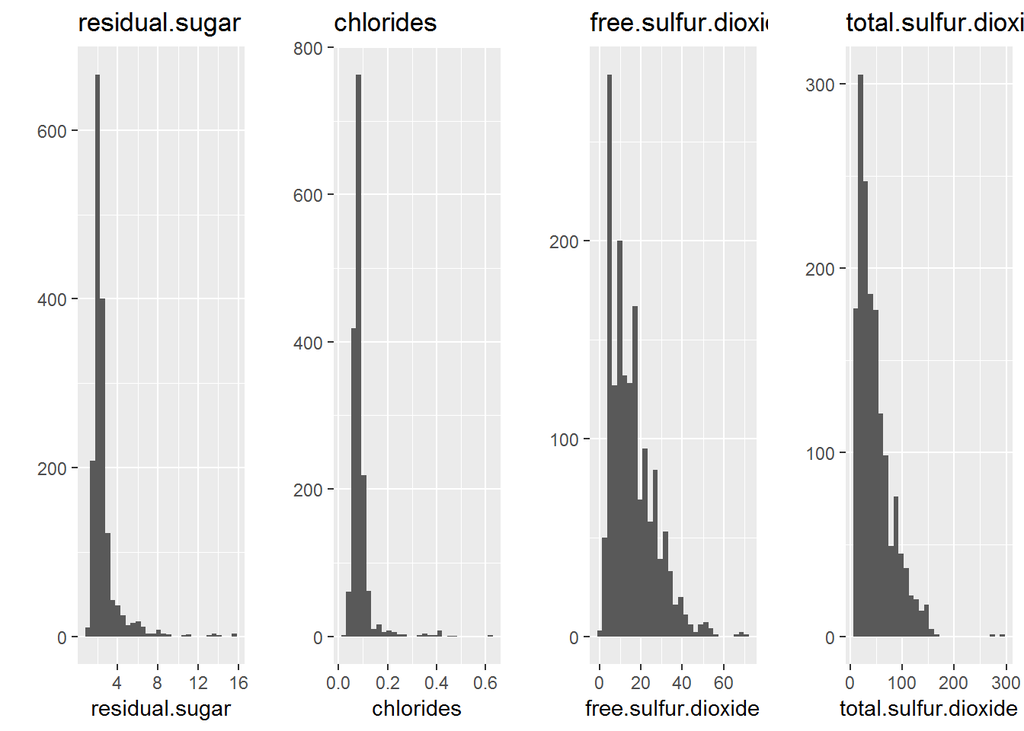

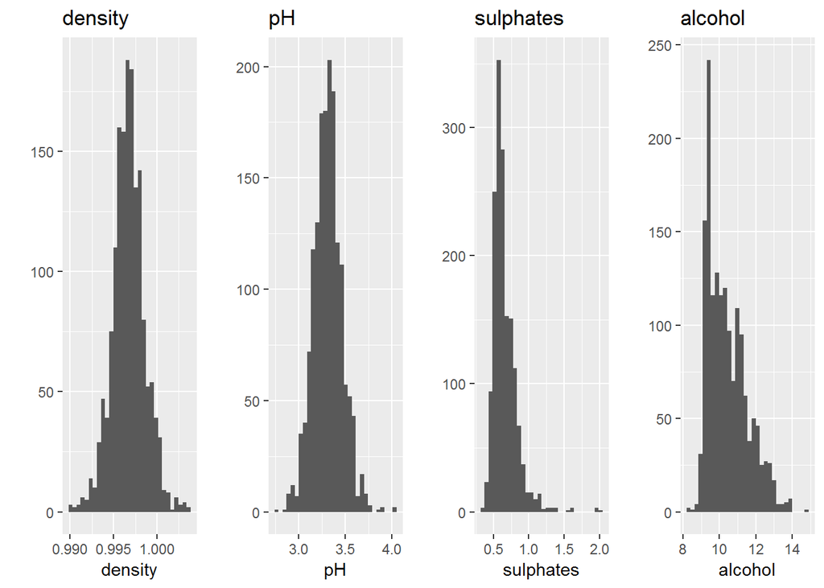

An alternative way to create one dimension plot for all variables using ggplot using geom_bar in case of quality then Alternative way by using geom_histogram

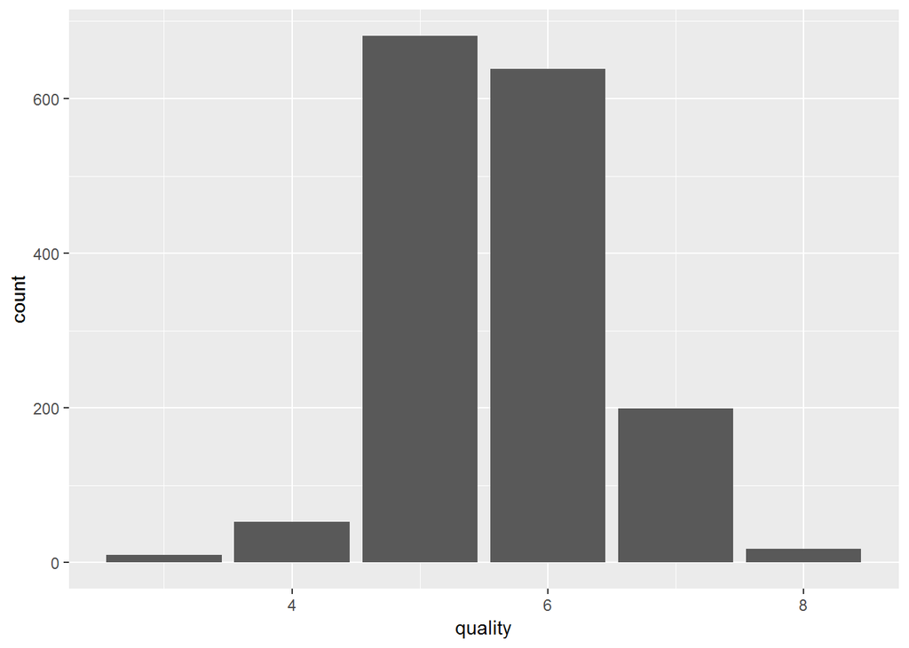

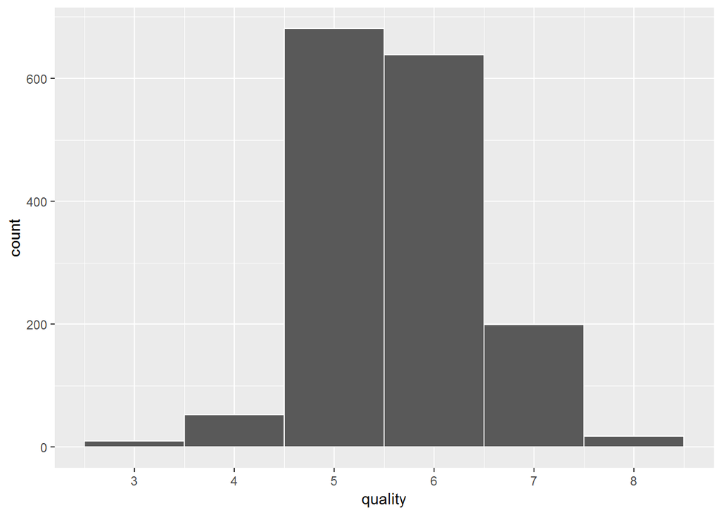

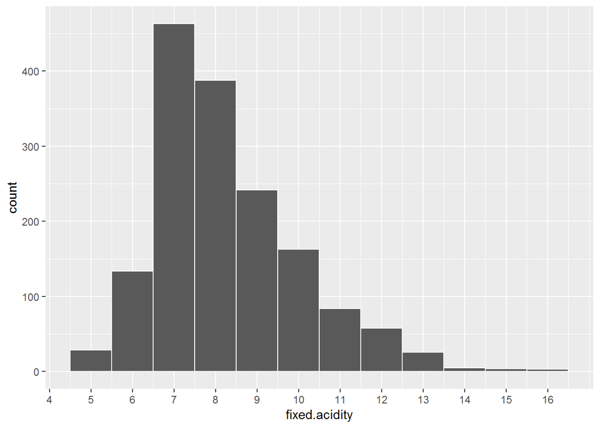

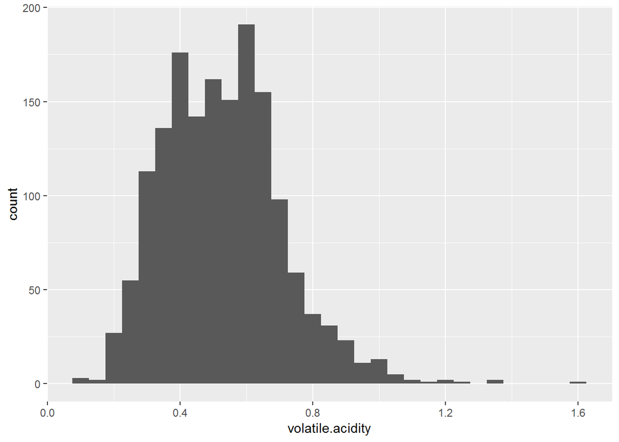

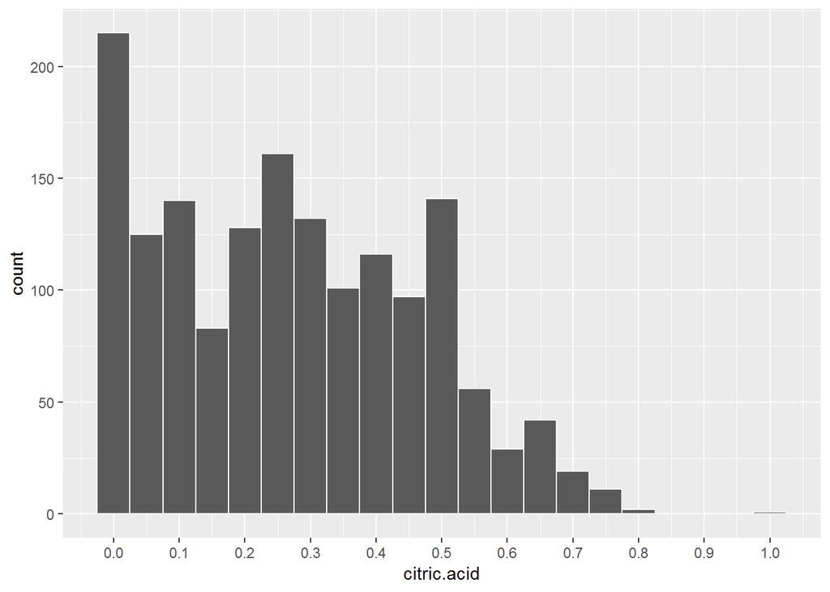

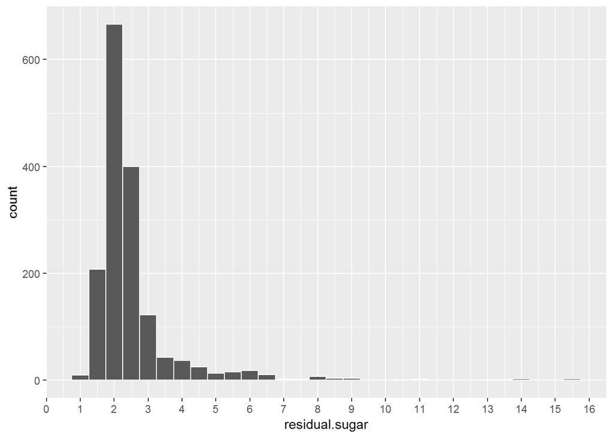

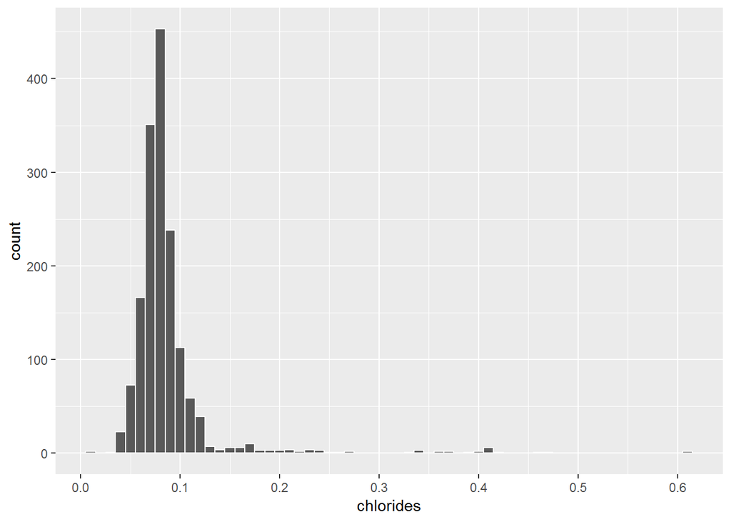

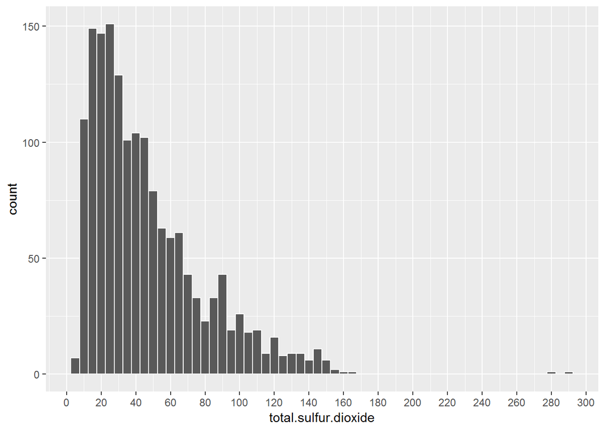

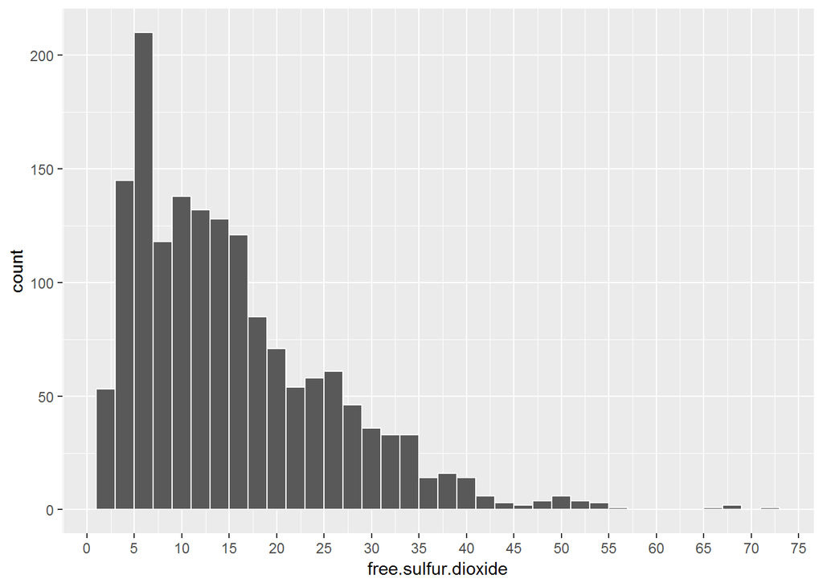

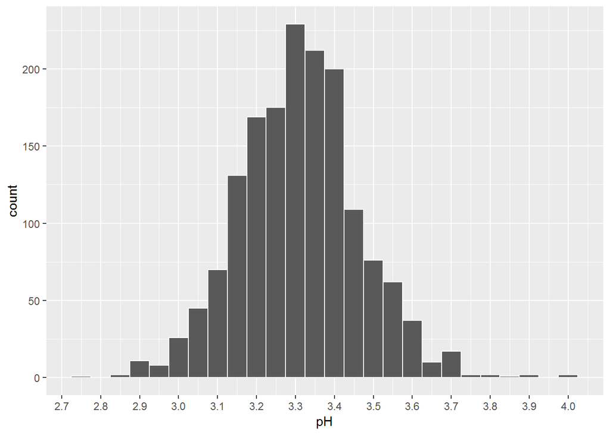

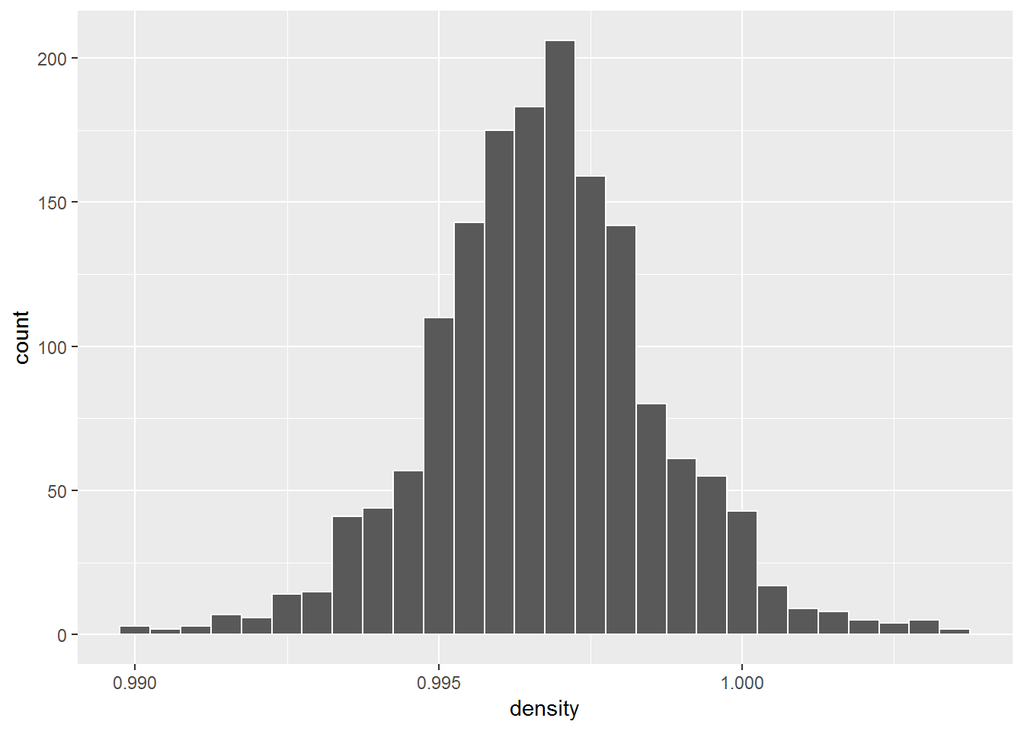

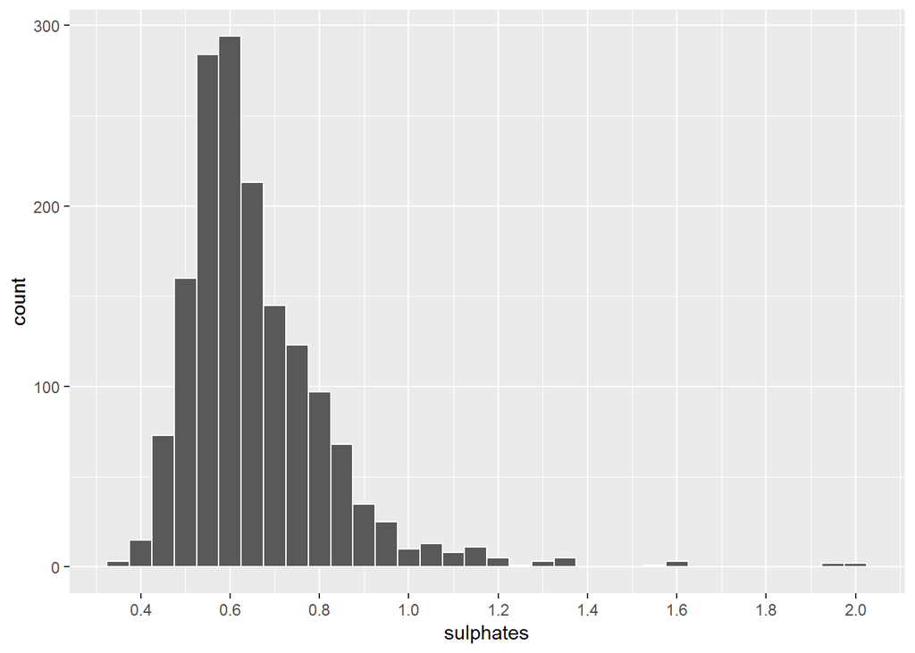

[1 more figures not shown]

# Univariate Plots Section

taking sqrt of volatile.acidity to get a better distribution.Addind details

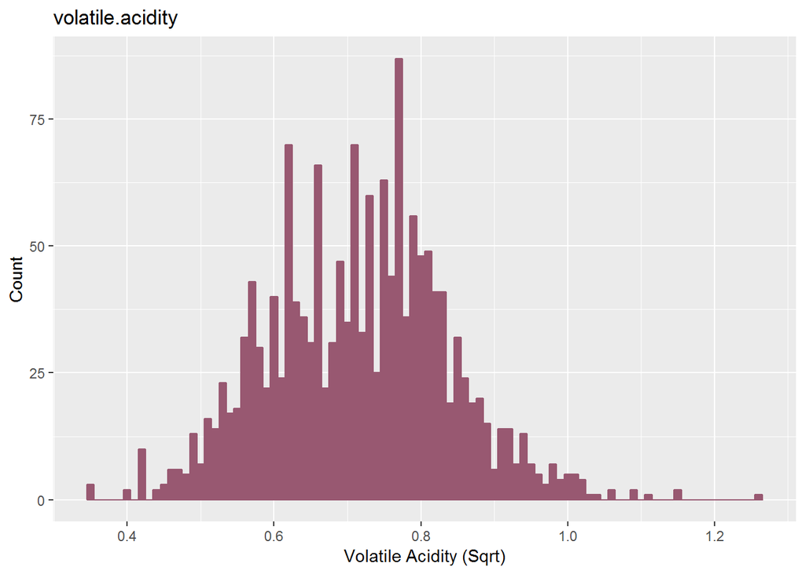

taking log10 of total.sulfur.dioxide to get a better distribution.Addind details

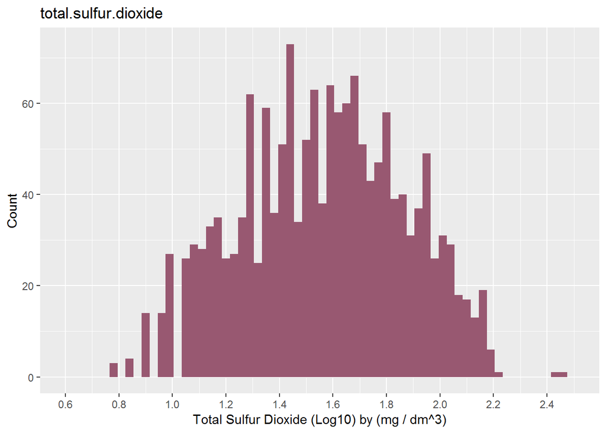

taking pH and addind details. Very clear normal distribution around 3.3

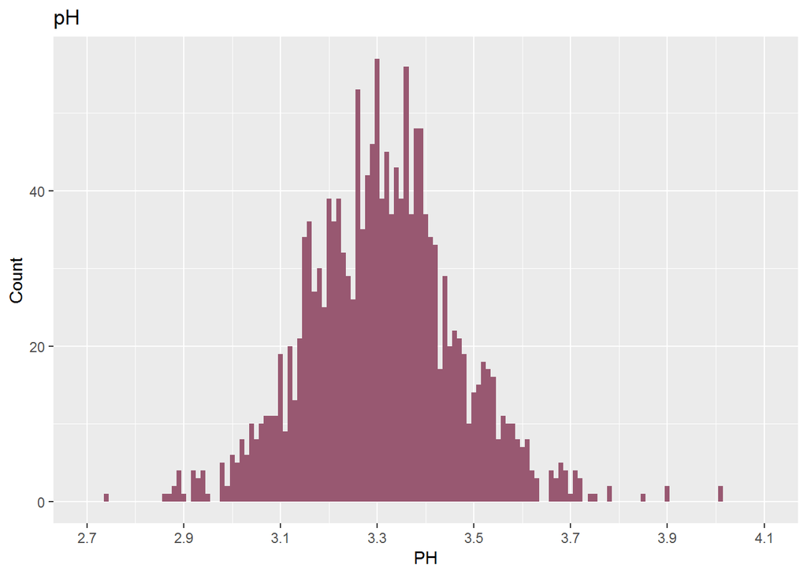

# Univariate Analysis

### What is the structure of your dataset?

We have 1599 observations and 13 variables. 11 variables are chemical elements that form wine. The last one is quality related.

### What is/are the main feature(s) of interest in your dataset?

My main goal here to get investigate red wine quality and what variables are impacting it. We need to investigate other variables too. Quality ranges from 3 - 8. normally distributed between 5, 6 and 7. Very a few counts on other quality values. Following are our distribution values, min = 3, 1st Qu. = 5, median = 6, mean = 5.63, 3rd Qu. = 6, and Max = 8

### Did you create any new variables from existing variables in the dataset?

Yes, I have created a new variable wine_quality: very.good >= 7, good >= 5, bad < 5

### Of the features you investigated, were there any unusual distributions? Did you perform any operations on the data to tidy, adjust, or change the form of the data? If so, why did you do this?

# Bivariate Plots Section

I need to take Correlation Coefficient to examine correlation between different variables COEF of fixed.acidity and citric.acid = 0.67 strong postive correlation. varified by plot

Plotting fixed acidity vs citric acid

```
## [1] 0.6717034
```

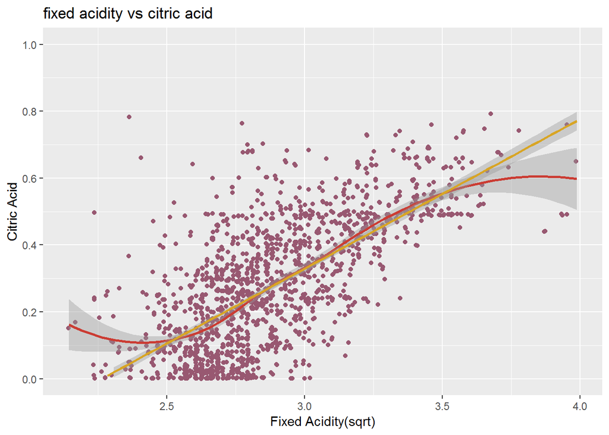

COEF of fixed.acidity and volatile.acidity = -0.25 slight negative correlation, varified by plots

```
## [1] -0.2561309
```

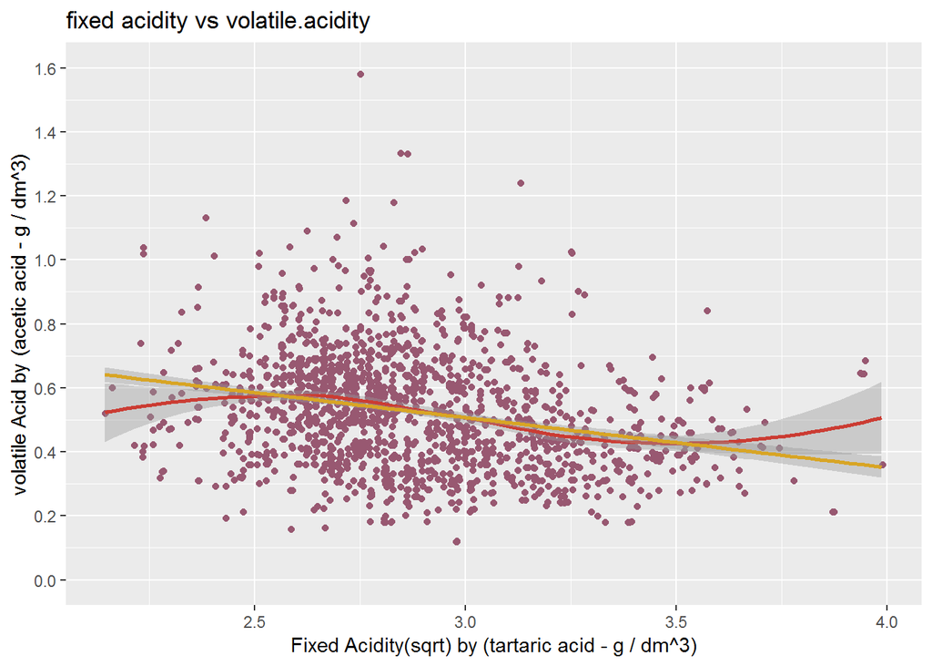

COEF of volatile.acidity and citric.acid = -0.55 strong negative correlation, varified by plots

```
## [1] -0.5524957
```

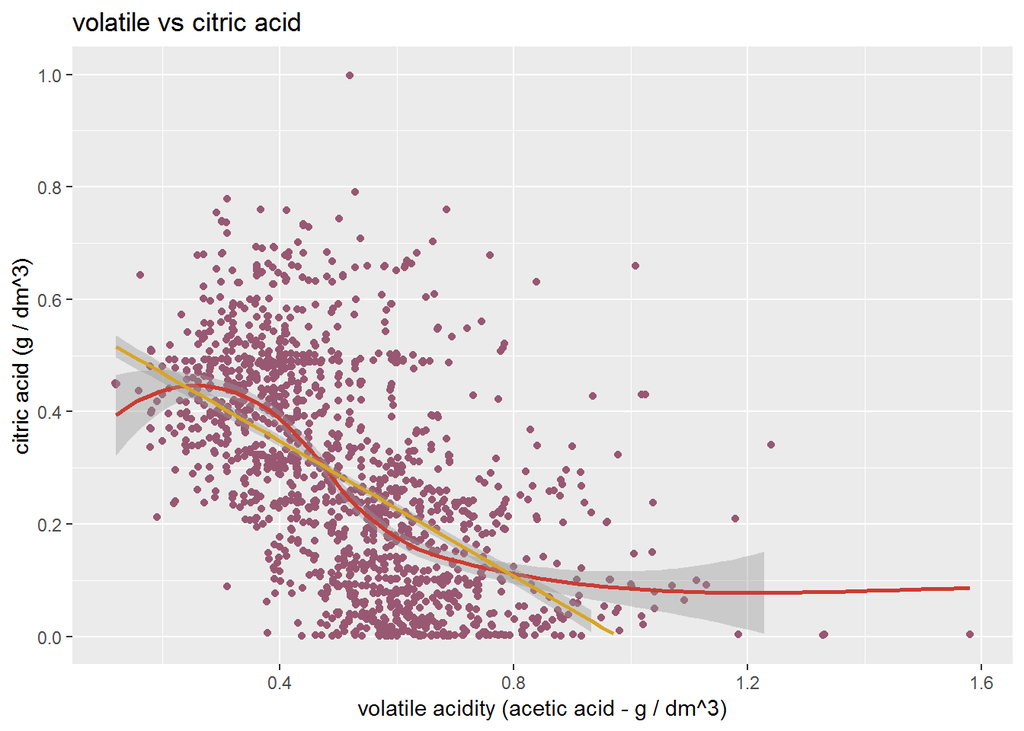

COEF of fixed.acidity and pH = -0.68 strong negative correlation, varified by plots

```
## [1] -0.6829782
```

[figure not shown]

Same we apply to correlation between quality and all variables what are strong postive and neagtive valriables to the quality

```
## [1] 0.1240516
```

```
## [1] -0.3905578
```

```
## [1] 0.2263725
```

```
## [1] 0.01373164
```

```
## [1] -0.1289066
```

```
## [1] -0.05065606
```

```
## [1] -0.1851003
```

```
## [1] -0.1749192
```

```
## [1] -0.05773139
```

```
## [1] 0.2513971
```

```
## [1] 0.4761663
```

Strongest positive correlation is with alcohol

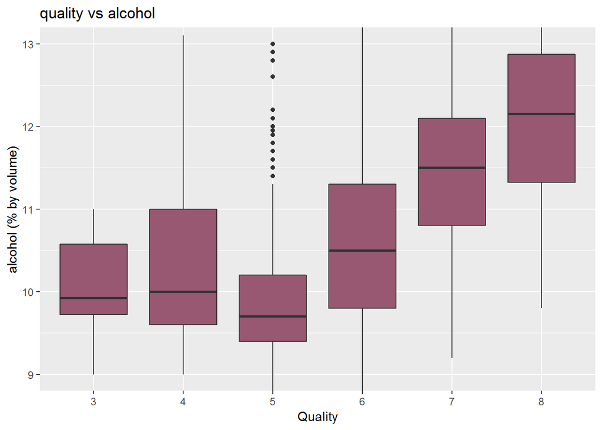

strogest negative correlation is with volatile.acidity

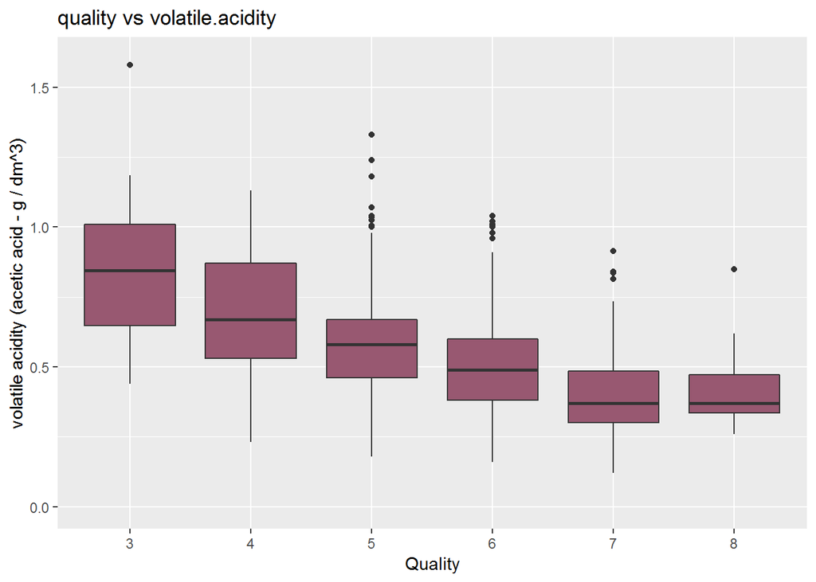

no correlation is with pH

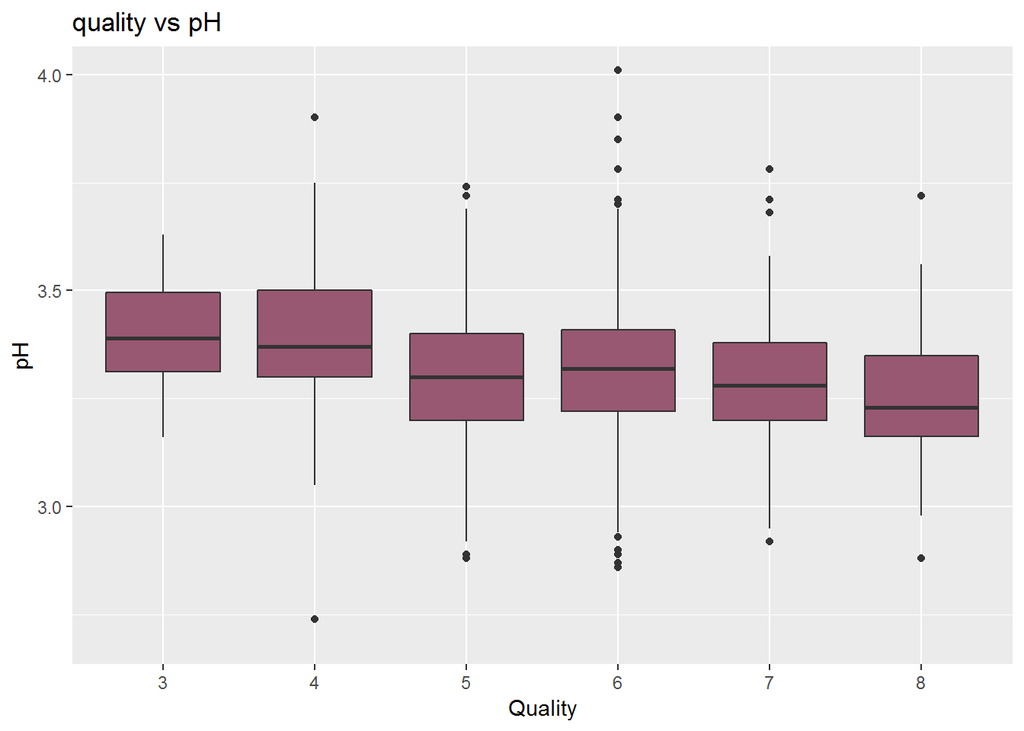

# Bivariate Analysis

### Talk about some of the relationships you observed in this part of the investigation. How did the feature(s) of interest vary with other features in the dataset?

Our conclusion was, the strongest positive relationship for the quality is was alcohol, while strongest negative is with volatile acidity, and there is no correlation between quality and both of pH and free sulfur dioxide. I used both of plots and COR function to verify my findings

### Did you observe any interesting relationships between the other features (not the main feature(s) of interest)?

I wanted to examine the correlation coefficient between acidity components and investigate relationships. I found out there is a strong positive correlation coefficient between fixed acidity and citric acid and it equals 0.67. For fixed acidity vs volatile acidity which is equal -0.25, there is a weak negative correlation. While volatile acidity vs citric acid equals -0.55 which a strong negative correlation coefficient. I used plots and COR function to cross check my findings.

### What was the strongest relationship you found?

# Multivariate Plots Section

In the multivariate plots I want to examine interesting facts about correlation Coefficient to invstigate both of the strong positive and strong negative to understand their behaviors with red wine quality using quality and wine_quality

Correlation between fixed acidity vs citric acid facet by quality variable Both have strong positive COR between themselves - Checking their relation with quality

Plotting fixed acidity vs citric acid coloring by quality and wine_quality

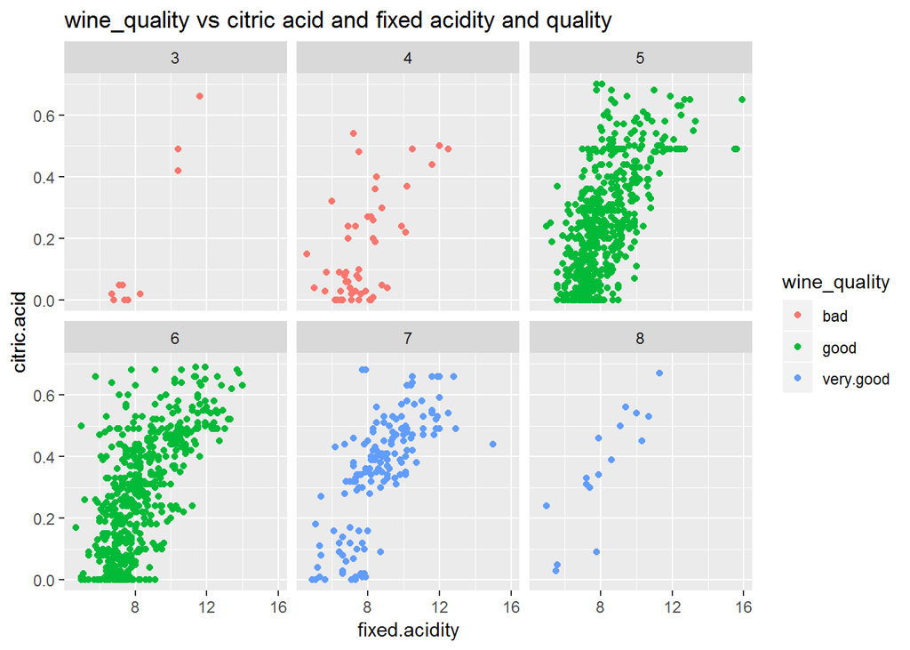

Strong negative correlation between fixed acidity and ph with quality

Plotting fixed acidity vs pH coloring by quality and wine_quality

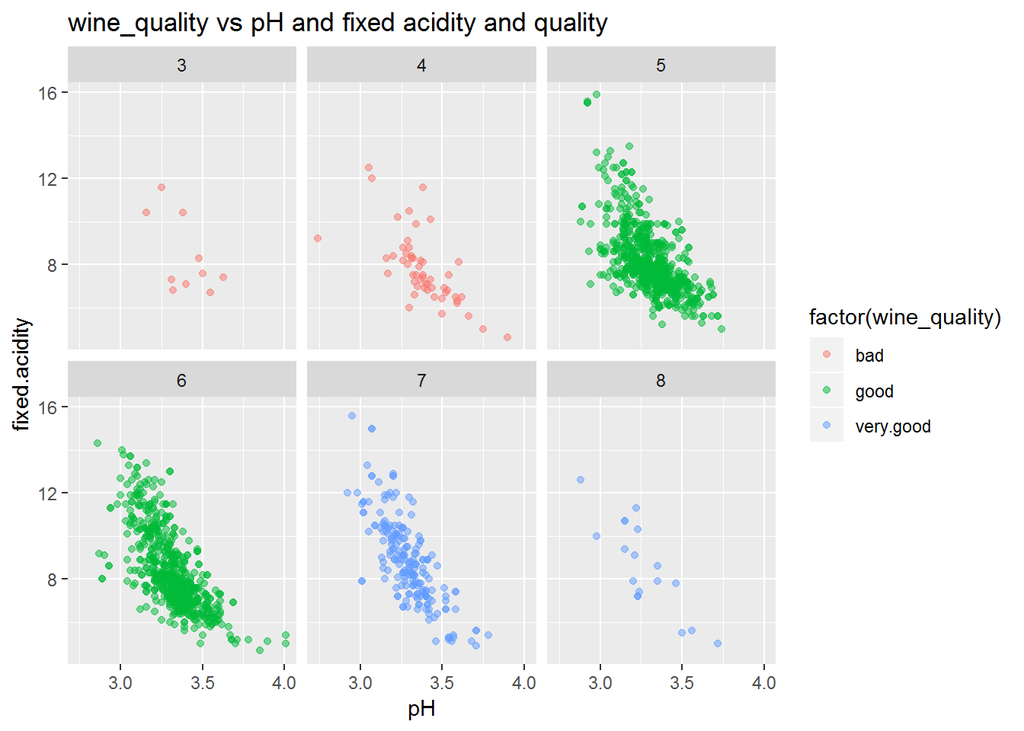

Grid arrange the strong positive and the strong negtive

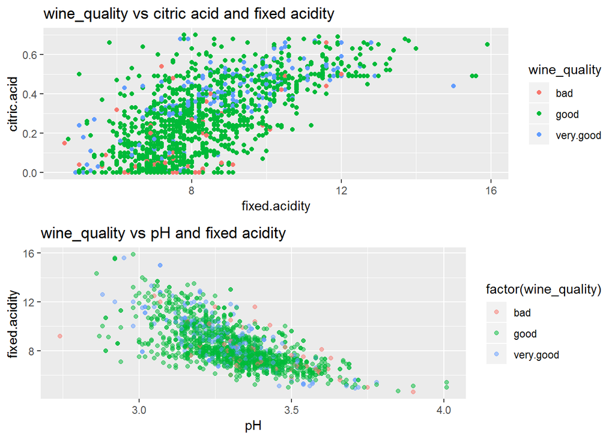

Some other interesting plots

wine_quality based on alcohol vs citric.acid and quality. Both have positive COR with quality but they don’t correlate

Plotting citric acid vs alcohol coloring by wine_quality

```
## [1] 0.1099032
```

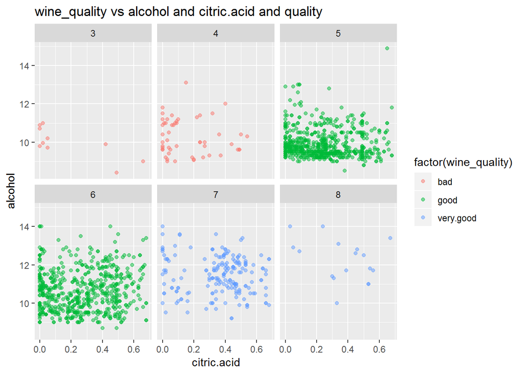

COEF of volatile.acidity and citric.acid = -0.55 strong negative correlation, varified by plots

Plotting citric acid vs volatile acidity

```
## [1] -0.5524957
```

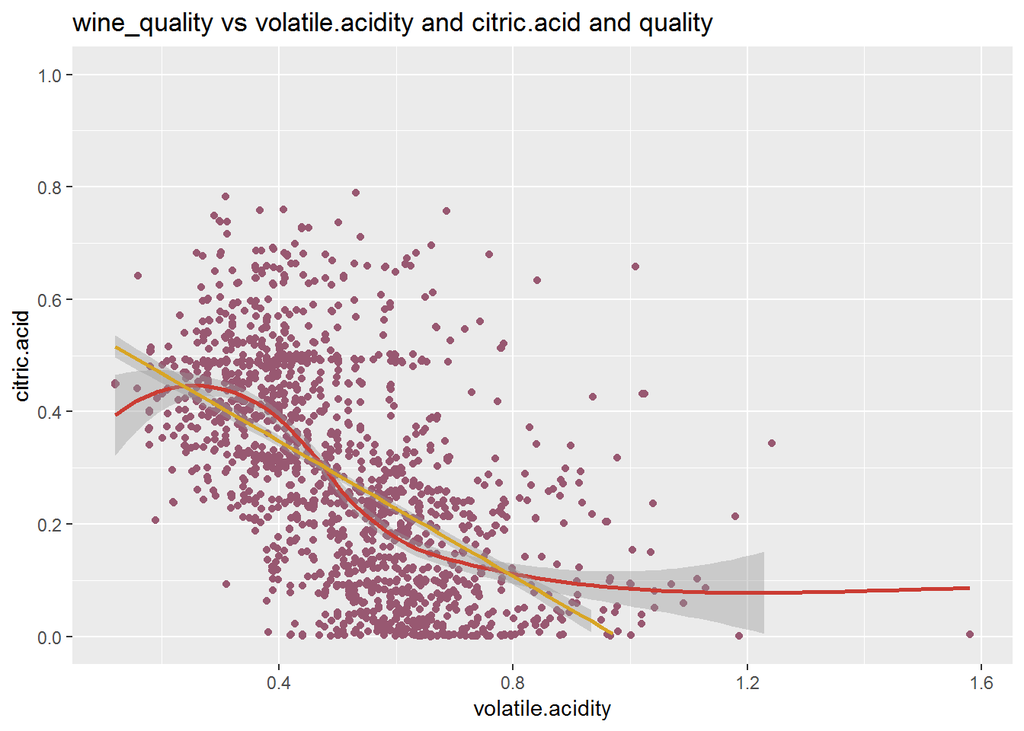

Another interesting fact about alcohol and density with COR = -0.49. Strong negative to be further analyzed later

Plotting density vs alcohol

```
## [1] -0.4961798
```

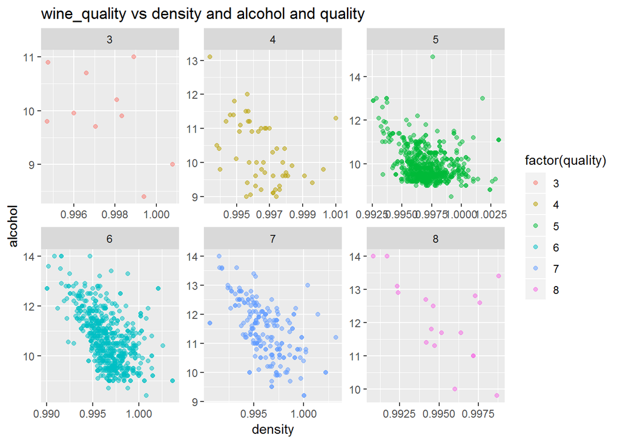

another interesting fact about citric acid and pH, COR = -0.54. Strong negative to be further analyzed later

Plotting pH vs citric acid

```
## [1] -0.5419041
```

[figure not shown]